# Working with phylogenies

Author

Jeet Sukumaran

## 1 Expressing phylogenies as Newick strings

A phylogeny can be expressed as a *Newick string*. That is, a *string* (in the computer science sense of a sequence of characters) in the “Newick” format. The Newick format is named after the lobster restaurant in which the format was sketched out on a napkin. Since its original formulation, there has been a large range of custom, specialized, idiosyncratic, or bespoke variants of Newick developed to accommodate different analysis needs, requirements, and preferences. Here we will go over the broad commonalities supported across most variants, with a ruleset that minimizes compatibility issues across different software implementations.

### 1.1 Phylogenetic trees expressed as Newick strings

A phylogenetic tree topology expressed in Newick format is a string of characters terminated by a semicolon, in which: Nodes are labeled with characters that include the standard alphanumeric characters, commas are used to separate nodes, while parentheses are used to group nodes into clades.

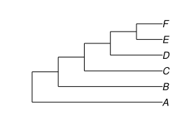

```
(A,(B,(C,(D,(E,F)))));
```

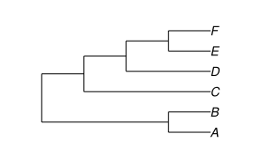

```
((A,B),(C,(D,(E,F))));
```

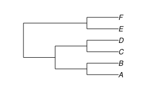

```
(((A,B),(C,D)),(E,F));
```

### 1.2 Internal node labels

Text placed immediately after the closing parenthesis for an internal node assigns a label to that node. The final label names the root node.

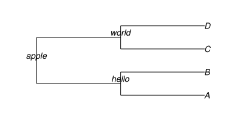

```
((A,B)hello,(C,D)world)apple;
```

### 1.3 Branch lengths

A colon followed by a number records the length of the branch subtending (incoming edge leading to) a node. These values can scale the branches in the visualization and can also be displayed as branch annotations.

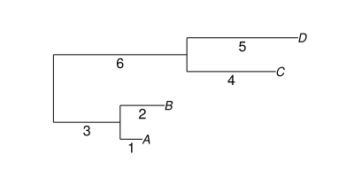

```
((A:1,B:2):3,(C:4,D:5):6):7;
```

### 1.4 Branch lengths and internal node labels

An internal node label follows its closing parenthesis, and the branch length follows that label after a colon.

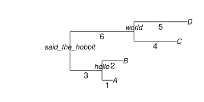

```
((A:1,B:2)hello:3,(C:4,D:5)world:6)said_the_hobbit:7;
```

In general, node labels can be safely composed with alphanumeric characters:

- Lowercase alphabetic characters: `a b c d e f g h i j k l m n o p q r s t u v w x y z`
- Uppercase alphabetic characters: `A B C D E F G H I J K L M N O P Q R S T U V W X Y Z`
- Numerals: `0 1 2 3 4 5 6 7 8 9`

In addition, the following characters are generally supported and can be used to make multipart labels easier to read:

- `.` (period)
- `_` (underscore). Some programs can translate underscores to spaces (so `Agkistrodon_sp` becomes `Agkistrodon sp`), as dictated by the original Newick standard, while others ignore this stipulation.

**WarningNewick-reserved characters**

In contrast, the following characters are used by the Newick format itself and will break parsers if they are used in unquoted labels:

- `-` (hyphen or dash)
- `(`, `)` (parentheses or rounded brackets)
- `:` (colon)

**NoteQuoted node labels**

In principle, the Newick format allows almost any character in node labels, including spaces and format-reserved characters, if and only if the label is wrapped in quotes. For example:

`(("Population 01 (N)","Population 01 (S)"),("Population 02 (N)","Population 03 (S)"));`

The above are not the full list of characters supported by Newick. They are, however, the *safest* to use when avoiding differences in support and parsing across programs, packages, and libraries. Beyond the above character set, different programs treat different characters differently. Most programs will error when the node labels include spaces, parentheses, dashes, brackets, as these break the Newick tokenizer. So, for robust pipelines, I recommend that you stick to the basic alphanumeric characters, with a period (“`.`”) as a separator if things look too squashed together. In fact, most informatics processing pipelines include a “label normalization” step, where all data labels are sanitized before any analysis to avoid issues with unsupported characters.

## 2 Parsing and reading phylogenies

Phylogenetic data can be parsed from string content or read from a file. In both cases, a format object states how PhyloMakie should interpret the data.

### 2.1 Parsing one phylogeny from string content

We use `PhyloMakie.parsephylogeny` to convert a string containing exactly 1 phylogeny into a `PhyloMakie.LineageNetwork` object. The function takes a format specification as its first argument and the phylogenetic content as its second argument. Here, `NewickFormat()` says that the content follows the Newick format.

For this example, we define the tree string explicitly in code: we “hard code” the data. In practice, the string might instead come from a file, a URL, a database query, a simulation, or an upstream informatics pipeline.

```julia
bears1_str = "(Giant_Panda, (Andean_Bear, ((Asian_Black_Bear, (Sun_Bear, Sloth_Bear)), (American_Black_Bear, (Brown_Bear, Polar_Bear)))));"
```

```
"(Giant_Panda, (Andean_Bear, ((Asian_Black_Bear, (Sun_Bear, Sloth_Bear)), (American_Black_Bear, (Brown_Bear, Polar_Bear)))));"
```

```julia
bears1_phylogeny = parsephylogeny(NewickFormat(), bears1_str)
```

```
LineageNetwork(15 nodes, 14 edges, 8 tips, 0 hybrid nodes, rooted)
```

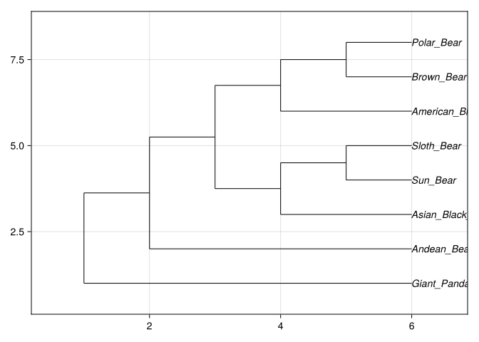

```julia
plot(bears1_phylogeny)
```

### 2.2 Parsing multiple phylogenies from string content

A data source can contain more than 1 phylogeny. In that case, we use `parsephylogenies`, which returns a *vector* of `LineageNetwork` objects. Here is a string containing multiple phylogenies:

```julia
alternative_bear_trees_str = """
((Giant_Panda,Andean_Bear),(Brown_Bear,Polar_Bear));
(Giant_Panda,(Andean_Bear,(Brown_Bear,Polar_Bear)));
(Polar_Bear,(Giant_Panda,(Brown_Bear,Andean_Bear)));
"""
```

```
"((Giant_Panda,Andean_Bear),(Brown_Bear,Polar_Bear));\n(Giant_Panda,(Andean_Bear,(Brown_Bear,Polar_Bear)));\n(Polar_Bear,(Giant_Panda,(Brown_Bear,Andean_Bear)));\n"
```

The plural parsing function returns these phylogenies in a vector.

```julia
bear_phylos = parsephylogenies(
    NewickFormat(),
    alternative_bear_trees_str,
)
```

```
3-element Vector{PhyloMakie.Phylogenies.LineageNetwork{Nothing, Nothing, Nothing}}:
 LineageNetwork(7 nodes, 6 edges, 4 tips, 0 hybrid nodes, rooted)
 LineageNetwork(7 nodes, 6 edges, 4 tips, 0 hybrid nodes, rooted)
 LineageNetwork(7 nodes, 6 edges, 4 tips, 0 hybrid nodes, rooted)
```

```julia
length(bear_phylos)
```

```
3
```

We can use the usual vector tools to select a single phylogeny.

```julia
# We use the `first()` function when we expect or need only the first result, or otherwise
# use standard vector iterators and accessors.
first_alternative = first(bear_phylos) # === bear_phylos[1]
```

```
LineageNetwork(7 nodes, 6 edges, 4 tips, 0 hybrid nodes, rooted)
```

```julia
first_alternative = bear_phylos[1]
second_alternative = bear_phylos[2]
third_alternative = bear_phylos[3]
```

```
LineageNetwork(7 nodes, 6 edges, 4 tips, 0 hybrid nodes, rooted)
```

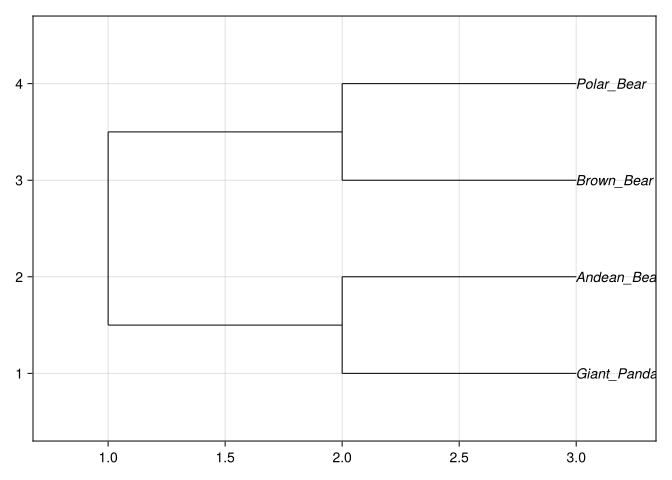

```julia
plot(first_alternative)
```

### 2.3 Creating and reading a Newick file

`parsephylogeny` and `parsephylogenies` treat a string as literal phylogenetic *content*. For a string that names a file on your computer, we instead use `readphylogeny` or `readphylogenies`.

Create that file now. Use the copy button on the following block, paste the text into a plain-text editor, and save it as `example-phylogenies.tre`. The file contains 3 short phylogenies, 1 per line.

```
((A:1,B:1)AB:2,(C:1,D:1)CD:2)root;
(A:1,(B:1,(C:1,D:1)CD:1)BCD:1)root;
((A:1,C:1)AC:2,(B:1,D:1)BD:2)root;
```

A reasonable default is your `Downloads` directory:

```julia
example_tree_path = joinpath(
    homedir(),
    "Downloads",
    "example-phylogenies.tre",
)
```

If you saved the file in a Julia learning project instead, use that path. For example, either of the following may match a directory that you created:

```julia
example_tree_path = joinpath(
    homedir(),
    "projects",
    "julia",
    "learning1",
    "data",
    "example-phylogenies.tre",
)

example_tree_path = joinpath(
    pwd(),
    "data",
    "example-phylogenies.tre",
)
```

Use the path to the location where *you* saved the file. Then confirm that Julia can find it before asking PhyloMakie to read it.

```julia
isfile(example_tree_path)
```

The file contains 3 phylogenies, so use the plural reader.

```julia
file_phylogenies = readphylogenies(
    NewickFormat(),
    example_tree_path,
)
```

```julia
length(file_phylogenies)
```

```julia
plot(first(file_phylogenies); useedgelength = true)
```

If a file must contain exactly 1 phylogeny, use the singular `readphylogeny` function instead.

### 2.4 Reading phylogenetic data from a URL

TreeBASE exposes published phylogenies through its web service. The following URL returns tree `Tr1453` directly in NEXUS format:

[Open or download TreeBASE tree Tr1453 as NEXUS](https://treebase.org/treebase-web/phylows/tree/TB2:Tr1453?format=nexus)

Julia’s standard-library `Downloads` module retrieves the response.

```julia
using Downloads
```

```julia
treebase_url = "https://treebase.org/treebase-web/phylows/tree/TB2:Tr1453?format=nexus"
```

```
"https://treebase.org/treebase-web/phylows/tree/TB2:Tr1453?format=nexus"
```

`Downloads.download` stores the response in a temporary file and returns its path. PhyloMakie’s NEXUS reader accepts a file path, so the download can feed directly into the reader without any repository checkout or bundled asset.

```julia
treebase_phylogenies = readphylogenies(
    NexusFormat(),
    Downloads.download(treebase_url),
)
```

```julia
length(treebase_phylogenies)
```

```julia
plot(first(treebase_phylogenies))
```

The `length` call should return `1`. Because TreeBASE is a remote service, a slow response or network interruption can require running the download cell again.

The function names therefore encode 2 decisions:

| Data source | Exactly 1 phylogeny | Zero or more phylogenies |
| --- | --- | --- |
| String content or an open `IO` stream | `parsephylogeny` | `parsephylogenies` |
| File path | `readphylogeny` | `readphylogenies` |

In each case, the format object—for example, `NewickFormat()` or `NexusFormat()`—states how PhyloMakie should interpret the source.

Back to top